# Accessibility Links

### Best Blood Pressure Monitors: 6 Expert-Ranked Brands 2024

US News Health

https://health.usnews.com › otc › rankings › blood-pres...

US News Health

https://health.usnews.com › otc › rankings › blood-pres...

Our panel of pharmacists ranked the best blood pressure monitor brands for home use, with *Omron* taking the top spot.

### Blood Pressure Monitors

CVS

https://www.cvs.com › ... › Home Health Care › Monitors

CVS

https://www.cvs.com › ... › Home Health Care › Monitors

Shop *CVS for Blood Pressure Monitors & Cuffs*! Browse a variety of brands like Omron and read reviews to find the blood pressure machine for you!

4.7store rating ([221](https://www.google.com/m/storepages?q=cvs.com&c=US)) · Free in-store returns

### Blood Pressure Monitors & Cuffs

Walgreens

https://www.walgreens.com › store › blood-pressure-mo...

Walgreens

https://www.walgreens.com › store › blood-pressure-mo...

We carry a large selection of *manual and automatic blood pressure monitors for home use*. You can explore the product assortment online and make a purchase, or ...

4.4store rating ([178](https://www.google.com/m/storepages?q=walgreens.com&c=US)) · $10 to $130 · Free 30-day returns

Popular products

[figure not shown]

Also nearby

Omron 5 Series Upper Arm Blood Pressure Monitor

$39.00

eBay & more

4.6(1.1K)

LOW PRICE

[figure not shown]

A&D Medical Premium Digital Blood Pressure Monitor

$44.99Usually $64

Midwest DME Supply & more

4.6(26)

[figure not shown]

Microlife BPM2 Advanced Blood Pressure Monitor

$39.99

Walgreens.com & more

Free delivery

4.7(13)

[figure not shown]

Also nearby

CVS Health Series 100 Upper Arm Blood Pressure Monitor

$19.95

eBay & more

4.8(45)

[figure not shown]

Omron BP7900 Complete Blood Pressure Monitor

$149.99

CVS Pharmacy & more

Get it by Fri (Free)

4.3(185)

[figure not shown]

Nearby, 11 mi

Walgreens Deluxe Arm Blood Pressure Monitor

$59.99

Walgreens.com & more

Get it today (Free)

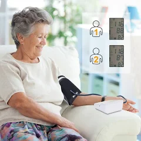

Omron 5 Series Upper Arm Blood Pressure Monitor BP742N

$27.99

eBay - topserviceshop & more

Free delivery

4.4(348)

[figure not shown]

Nearby, 1 mi

Homedics 400 Series Upper Arm Blood Pressure Monitor

$54.99

CVS Pharmacy & more

Get it by Fri (Free)

4.5(24)

LOW PRICE

[figure not shown]

Omron Silver Blood Pressure Monitor

$56.00Usually $89

Amazon & more

4.6(28)

14% OFF

[figure not shown]

Nearby, 3 mi

Withings BPM Connect Smart Blood Pressure Monitor

$84.99$100

Best Buy & more

4.5(2.4K)

[figure not shown]

Nearby, 2 mi

Omron 5 Series Wireless Upper Arm Blood Pressure Monitor with Adapter

$54.99

Target & more

Get it today ($10)

4.4(378)

35% OFF

[figure not shown]

Omron Bronze Upper Arm Blood Pressure Monitor

$29.00$45

Amazon & more

5.0(1)